# Assignment 02 - Description

## 5143135: Computer Graphics @ ZJU School of Software Technology

### Fall 2023: Assignment 2

**Assessment:** Assignment 2 has in total **4** tasks and **100** points, and is worth **15%** of the final result for this course.

**Due Date:** 5 November 2023, Sunday, at 11:30 PM.

Late submission will NOT be accepted, unless an extension has been approved by the hosting lecturer.

**Plagiarism:** Plagiarism is the representation of another author's output as one's own original work, and is considered academic misconduct. The University treats academic misconduct seriously. When plagiarism is detected, penalties will be strictly imposed.

**Submission Details:** Compress all required files into a ZIP file, name it your student number, and submit it to the host lecturer (t.feng@zju.edu.cn) by email before the due date.

**Testing Platform:** All submitted programs will be tested on Windows 10 22H2 with Python 3.8.

**Return of Assignment:** The hosting lecturer will mark the assignment according to a marking sheet and return the filled sheet to each student after marking.

**Operations on Text File I/O and Strings in Python:** You are required to survey online or in a textbook how to enable operations on text file I/O and strings in Python for Task 2 and 3.

**Attachment:**

- ZJUSST-CG-2023-A2-Marking-Sheet.pdf (marking sheet)
- Update on the illustration for Assignment 2.pdf

### Task 1: Ray Casting with Ray-Triangle Intersections (30 Points)

Based on the provided material in Lab 5, write a Python program one.py without PyOpenGL to enable **ray-triangle intersections** in ray casting, which satifies the following requirements:

- The program outputs an image file in PNG format, named **one.png**, of size **500 px * 500px**;
- The program includes a function named *addTriangle* for adding a triangle object to the scene, which takes **6 arguments**; All arguments are **lists with 3 elements**; The first 3 arguments are x-y-z coordinates of the 3 vertices; The rest 3 arguments are RGB colors assigned to the 3 vertices;
- At any point in a triangle, the normal is **explicitly calculated** and its **z-coordiante** is assumed to be **negative**;
- At any point in a triangle, the color is the **barycentric interpolation** of the colors assigned to the 3 vertices;
- In the Phong reflection model, only ambient and diffuse reflections are considered.

Suppose the statement for the scene objects is as follows,

```python
# List of objects
scene = [
    add_plane([0.0, -0.5, 0.0], [0.0, 1.0, 0.0]),
    add_triangle([-0.1, 0.0, 0.1], [0.1, 0.0, 0.1], [0.0, 0.2, 0.1], [1.0, 0.0, 0.0], [0.0, 1.0, 0.0], [0.0, 0.0, 1.0]),
    add_triangle([-0.1, 0.0, 0.1], [0.0, 0.2, 0.1], [-0.2, 0.2, 0.3], [1.0, 0.0, 0.0], [0.0, 0.0, 1.0], [1.0, 0.0, 1.0]),
    add_triangle([0.1, 0.0, 0.1], [0.0, 0.2, 0.1], [0.2, 0.2, 0.3], [0.0, 1.0, 0.0], [0.0, 0.0, 1.0], [0.0, 1.0, 1.0])
]
```

The following image illustrates the expected output.

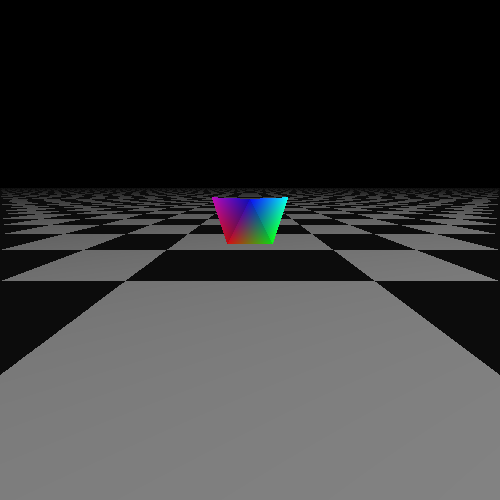

### Task 2: Advanced Ray Tracing (45 Points)

Based on the provided material in Lab 6, write a Python program two.py without PyOpenGL to enable **multiple lights** and **recursive reflections** in ray tracing, which satifies the following requirements:

- The program outputs an image file in PNG format, named **two.png**, of size **400 px * 400px**;
- **More than 1 point lights are supported**, given their **locations** and **colors**;
- The module of reflections is implemented in a **recursive** way (i.e., part of the *trace_ray* function);
- **Recursive depth is supported** (i.e., maximum number of bounces).
- In the Phong reflection model, all modules are considered.

Suppose the statements for lights and scene objects are as follows,

```python
# Number of lights
num_lights = 2

# Positions of lights
position_lights     = [
                        np.array([5.0, 5.0, -10.0]),
                        np.array([-5.0, 5.0, -10.0])
                    ]

# Colors of lights
color_lights        = [
                        np.array([1.0, 1.0, 1.0]),
                        np.array([1.0, 1.0, 0.0])
                    ]

# List of objects
scene = [
    add_sphere([1.0, 0.0, 1.0], 0.5, [1.0, 0.0, 0.0]),
    add_sphere([0.0, -0.1, 2.0], 0.4, [0.0, 0.0, 1.0]),
    add_sphere([-1.0, -0.2, 1.0], 0.3, [1.0, 1.0, 0.0]),
    add_sphere([-0.5, -0.3, 0.2], 0.2, [0.0, 1.0, 0.0]),
    add_plane([0.0, -0.5, 0.0], [0.0, 1.0, 0.0]),
]
```

If the recursive depth is **0**, the following image illustrates the expected output,

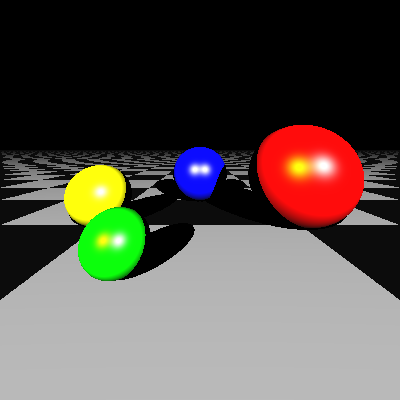

If the recursive depth is **1**, the following image illustrates the expected output,

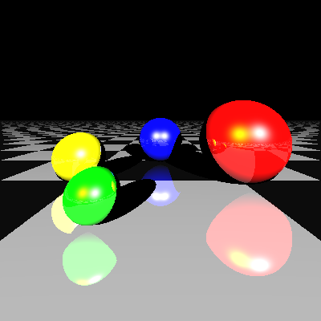

If the recursive depth is **2**, the following image illustrates the expected output,

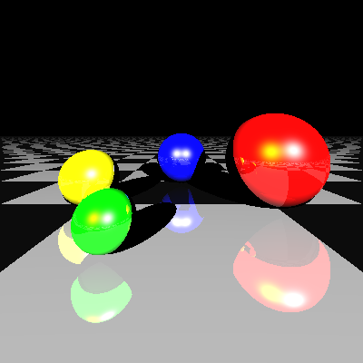

If the recursive depth is **3**, the following image illustrates the expected output,

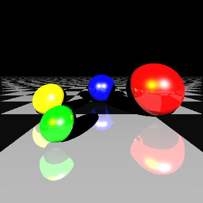

### Task 3: Controlled Fireworks (15 Points)

Based on the provided material in Lab 7, write a Python program three.py with PyOpenGL to enable **fireworks** controlled by **keyboard**, which satifies the following requirements:

- The window application's size is (500, 500), and its upper-left corner is at (100, 100) on the screen;
- The window application's title is **Fireworks**.
- When the key **F** is pressed, the program creates a firework with a randomized location on the x-y plane and a randomized exploding color, and then simulates it.
- When the key **S** is pressed, the program toggles between being paused and simulating.
- The program is able to simulate multiple fireworks at the same time.

The following figure illustrates the expected window application.

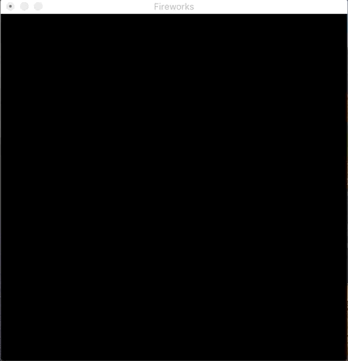

### Task 4: Report (10 Points)

Write a report four.pdf in PDF format, answering the following questions related to each of the above tasks (if accomplished):

- What is your general solution to the task?
- Which part of the task is the most difficult in your opinion? And why?
- Which areas or scenarios may benefit from your solution to the task?
- How would you improve the program's effciency if asked to do so?

(THIS IS THE END OF THE ASSIGNMENT.)